# Presentation

Water Management Project Group

2023-06-16

#Drip Irrigation adoption in Kenya Irrigation schemes #Inroduction Why that Decision- ? Due to Climate change effects especially the increased events of drought conditions in Kenya, there is a need for proper management and utilization of water resources. Surface irrigation system comprises the biggest percentage in Kenya Irrigation Schemes thus drawing a lot of water from the landscape and negative effect cosharing entities. Therefore we want the government of Kenya to buy into the idea of Drip Irrigation as a sustainable water management approach in the various Irrigation Schemes.

Decision Makers- Government of Kenya will be the Decision Makers who also do stakeholder analysis.

#The Project`s Stakeholders The individual/group who has interests/can affect/ is affected by the decision.

After brainstorming and with the help of the STRATEGIC PLAN (2019-2023) by National Irrigation Authority, decided to work on 14 stakeholders. For each of them, defined : -Roles -Major one -Rated : -Capital availability -Influence -Expertise

In the purpose of analyse it and define most important stakeholders and the decision maker Plot #capital availability, #expertise, #influence.

```r
library(ggplot2)
library(ggrepel)
library(ggthemes)
library(readr)
library(dplyr)
stakeholder<-read.csv("Stakeholder Management data.csv")

#print(Stakeholder_Management_data)

ggplot(data = stakeholder, aes(x = Expertise,
                               y = Capital_Availability,
                               label = Stakeholders,
                               color = Influence))+
  geom_point() +
  xlab("Expertise") +

  #label names of stakeholders and expand space to show full names
  scale_x_continuous(labels = paste(seq(0, 5, by = 1)),
                     breaks = seq(0, 5, by = 1),
                     limits = c(0, 5),
                     expand = c(0, 1)) +
  scale_y_continuous(labels = paste(seq(0, 5, by = 1)),
                     breaks = seq(0, 5, by = 1),
                     limits = c(0, 5),
                     expand = c(0, 1)) +
  theme(plot.margin = unit(c(1, 1, 1, 1), "cm")) +
  theme(legend.position = "none") +

  # Create line to categorize stakeholders
  geom_hline(yintercept=2.5, color="white", size=2) +
  geom_vline(xintercept=2.5, color="white", size=2) +

  # Show all names of overlapped values
  geom_text_repel(box.padding = 0.3, max.overlaps = Inf, size = 3) +
  annotate("text", label = "Potential core experts",
           x = 4.5, y = 3.5, size = 5, color = "grey48") +
  annotate("text", label = "Resource persons",
           x = 4.5, y = 0.25, size = 5, color = "grey48")
```

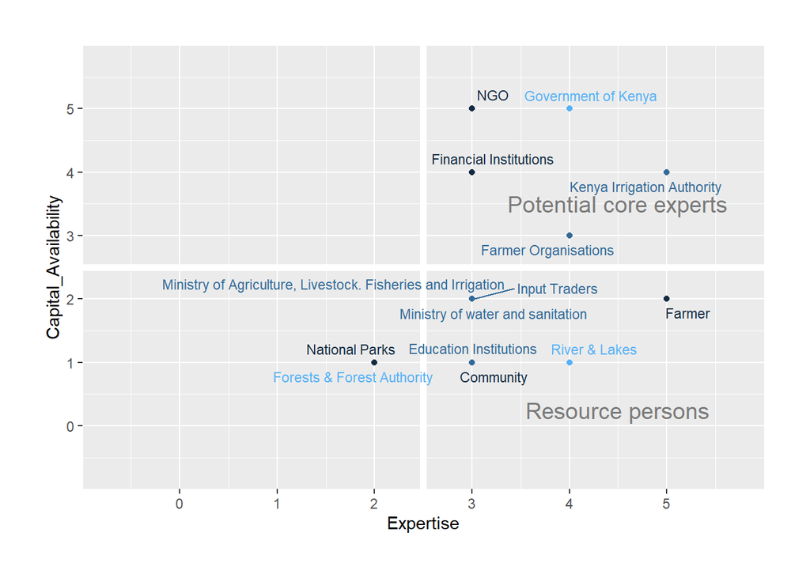

[figure not shown]

Government, NGO, irrigation authority = most important (as expected) It confirms our choice to work with the Government as the decision maker.